# Loan Data Exploration

## Preliminary Wrangling

> This data set contains 113,937 loans with 81 variables on each loan, including loan amount, borrower rate (or interest rate), current loan status, borrower income, and many other

```python
# import all packages and set plots to be embedded inline
import numpy as np
import pandas as pd
import matplotlib.pyplot as plt
import seaborn as sb

%matplotlib inline
```

> Loading dataset and describing its properties

```python
#load data
loan= pd.read_csv('prosperLoanData.csv')
loan.head()
```

|  | ListingKey | ListingNumber | ListingCreationDate | CreditGrade | Term | LoanStatus | ClosedDate | BorrowerAPR | BorrowerRate | LenderYield | ... | LP_ServiceFees | LP_CollectionFees | LP_GrossPrincipalLoss | LP_NetPrincipalLoss | LP_NonPrincipalRecoverypayments | PercentFunded | Recommendations | InvestmentFromFriendsCount | InvestmentFromFriendsAmount | Investors |
| --- | --- | --- | --- | --- | --- | --- | --- | --- | --- | --- | --- | --- | --- | --- | --- | --- | --- | --- | --- | --- | --- |
| 0 | 1021339766868145413AB3B | 193129 | 2007-08-26 19:09:29.263000000 | C | 36 | Completed | 2009-08-14 00:00:00 | 0.16516 | 0.1580 | 0.1380 | ... | -133.18 | 0.0 | 0.0 | 0.0 | 0.0 | 1.0 | 0 | 0 | 0.0 | 258 |
| 1 | 10273602499503308B223C1 | 1209647 | 2014-02-27 08:28:07.900000000 | NaN | 36 | Current | NaN | 0.12016 | 0.0920 | 0.0820 | ... | 0.00 | 0.0 | 0.0 | 0.0 | 0.0 | 1.0 | 0 | 0 | 0.0 | 1 |
| 2 | 0EE9337825851032864889A | 81716 | 2007-01-05 15:00:47.090000000 | HR | 36 | Completed | 2009-12-17 00:00:00 | 0.28269 | 0.2750 | 0.2400 | ... | -24.20 | 0.0 | 0.0 | 0.0 | 0.0 | 1.0 | 0 | 0 | 0.0 | 41 |
| 3 | 0EF5356002482715299901A | 658116 | 2012-10-22 11:02:35.010000000 | NaN | 36 | Current | NaN | 0.12528 | 0.0974 | 0.0874 | ... | -108.01 | 0.0 | 0.0 | 0.0 | 0.0 | 1.0 | 0 | 0 | 0.0 | 158 |
| 4 | 0F023589499656230C5E3E2 | 909464 | 2013-09-14 18:38:39.097000000 | NaN | 36 | Current | NaN | 0.24614 | 0.2085 | 0.1985 | ... | -60.27 | 0.0 | 0.0 | 0.0 | 0.0 | 1.0 | 0 | 0 | 0.0 | 20 |

5 rows × 81 columns

```python
loan.shape
```

```
(113937, 81)
```

```python
loan.info()
```

```
<class 'pandas.core.frame.DataFrame'>
RangeIndex: 113937 entries, 0 to 113936
Data columns (total 81 columns):
 #   Column                               Non-Null Count   Dtype
---  ------                               --------------   -----
 0   ListingKey                           113937 non-null  object
 1   ListingNumber                        113937 non-null  int64
 2   ListingCreationDate                  113937 non-null  object
 3   CreditGrade                          28953 non-null   object
 4   Term                                 113937 non-null  int64
 5   LoanStatus                           113937 non-null  object
 6   ClosedDate                           55089 non-null   object
 7   BorrowerAPR                          113912 non-null  float64
 8   BorrowerRate                         113937 non-null  float64
 9   LenderYield                          113937 non-null  float64
```

[output cut: 73 more lines]

### The structure of your dataset

> The dataset has 81 features and 113937 enteries. We now need to explore only those variables which are needed for our analysis

### The main feature(s) of interest in the dataset

> Main feature of interest here is to analyse what guides the APR(Annual Percentage rate for a loan) of borrower for a loan

### What features in the dataset do you think will help support your investigation into your feature(s) of interest?

> ```
>       'Term',
>        'LoanOriginalAmount',
>        'BorrowerAPR',
>        'BorrowerRate',
>        'StatedMonthlyIncome',
>        'ProsperRating (Alpha)',
>        'ProsperScore',
>        'BorrowerState',
>        'Occupation',
>        'EmploymentStatus',
> ```

```python
col_list= ['Term',
           'LoanOriginalAmount',
           'BorrowerAPR','BorrowerRate',
           'ProsperRating (Alpha)',
           'ProsperScore',
           'BorrowerState',
           'Occupation',
           'EmploymentStatus',
           'StatedMonthlyIncome'
          ]
sub_loan= loan[col_list]
sub_loan.head()
```

|  | Term | LoanOriginalAmount | BorrowerAPR | BorrowerRate | ProsperRating (Alpha) | ProsperScore | BorrowerState | Occupation | EmploymentStatus | StatedMonthlyIncome |
| --- | --- | --- | --- | --- | --- | --- | --- | --- | --- | --- |
| 0 | 36 | 9425 | 0.16516 | 0.1580 | NaN | NaN | CO | Other | Self-employed | 3083.333333 |
| 1 | 36 | 10000 | 0.12016 | 0.0920 | A | 7.0 | CO | Professional | Employed | 6125.000000 |
| 2 | 36 | 3001 | 0.28269 | 0.2750 | NaN | NaN | GA | Other | Not available | 2083.333333 |
| 3 | 36 | 10000 | 0.12528 | 0.0974 | A | 9.0 | GA | Skilled Labor | Employed | 2875.000000 |
| 4 | 36 | 15000 | 0.24614 | 0.2085 | D | 4.0 | MN | Executive | Employed | 9583.333333 |

```python
#checking null values
sub_loan.info()
```

```
<class 'pandas.core.frame.DataFrame'>
RangeIndex: 113937 entries, 0 to 113936
Data columns (total 10 columns):
 #   Column                 Non-Null Count   Dtype
---  ------                 --------------   -----
 0   Term                   113937 non-null  int64
 1   LoanOriginalAmount     113937 non-null  int64
 2   BorrowerAPR            113912 non-null  float64
 3   BorrowerRate           113937 non-null  float64
 4   ProsperRating (Alpha)  84853 non-null   object
 5   ProsperScore           84853 non-null   float64
 6   BorrowerState          108422 non-null  object
 7   Occupation             110349 non-null  object
 8   EmploymentStatus       111682 non-null  object
 9   StatedMonthlyIncome    113937 non-null  float64
dtypes: float64(4), int64(2), object(4)
memory usage: 8.7+ MB
```

```python
#removing rows with null borrower APR
sub_loan= sub_loan.dropna(subset=['BorrowerAPR'])
#checking if null values are dropped
sub_loan.info()
```

```
<class 'pandas.core.frame.DataFrame'>
Int64Index: 113912 entries, 0 to 113936
Data columns (total 10 columns):
 #   Column                 Non-Null Count   Dtype
---  ------                 --------------   -----
 0   Term                   113912 non-null  int64
 1   LoanOriginalAmount     113912 non-null  int64
 2   BorrowerAPR            113912 non-null  float64
 3   BorrowerRate           113912 non-null  float64
 4   ProsperRating (Alpha)  84853 non-null   object
 5   ProsperScore           84853 non-null   float64
 6   BorrowerState          108422 non-null  object
 7   Occupation             110349 non-null  object
 8   EmploymentStatus       111682 non-null  object
 9   StatedMonthlyIncome    113912 non-null  float64
dtypes: float64(4), int64(2), object(4)
memory usage: 9.6+ MB
```

## Univariate Exploration

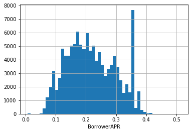

```python
sub_loan['BorrowerAPR'].hist(bins=50)
plt.xlabel('BorrowerAPR')
plt.figsize=[10,7];
```

> Distribution here looks like multimodal. A small peak was observed at 0.1, a large peak around 0.2 and another small peak centred at 0.3. A really large peak is seen around 0.35 and 0.36. Furthermore, only few loans have APR greater than 0.45

```python
sub_loan[sub_loan.BorrowerAPR>0.45]
```

|  | Term | LoanOriginalAmount | BorrowerAPR | BorrowerRate | ProsperRating (Alpha) | ProsperScore | BorrowerState | Occupation | EmploymentStatus | StatedMonthlyIncome |
| --- | --- | --- | --- | --- | --- | --- | --- | --- | --- | --- |
| 18326 | 36 | 3000 | 0.45857 | 0.4500 | NaN | NaN | NaN | NaN | NaN | 10000.000000 |
| 22195 | 36 | 1789 | 0.46201 | 0.4500 | NaN | NaN | NaN | NaN | NaN | 2916.666667 |
| 36018 | 36 | 1500 | 0.51229 | 0.4975 | NaN | NaN | NaN | NaN | NaN | 2838.000000 |
| 56761 | 36 | 3000 | 0.50633 | 0.4975 | NaN | NaN | NaN | NaN | NaN | 0.000000 |
| 82043 | 36 | 3000 | 0.48873 | 0.4800 | NaN | NaN | NaN | NaN | NaN | 1583.333333 |
| 103973 | 36 | 2800 | 0.45857 | 0.4500 | NaN | NaN | NaN | NaN | NaN | 3750.000000 |

> Borrowers with APR above 0.45 don't have prosper rating,ProsperScore, employment status and Occupation data. We also observe that tha loan amount is low too

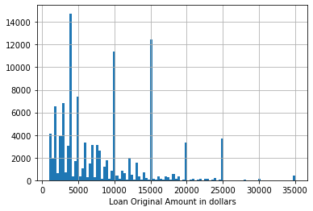

```python
sub_loan['LoanOriginalAmount'].hist(bins=100)
plt.xlabel('Loan Original Amount in dollars')
plt.figsize=[10,7];
```

> Large spikes observed at 10k,15k,20k,25k which concludes that loan are given in amounts multiple of 10 Small quantity loans are more in number

```
1750002.916667
```

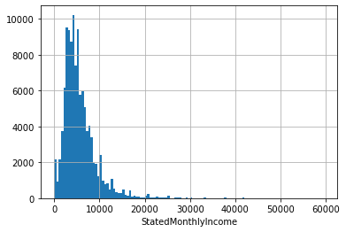

```python
x= np.arange(0,60000, 500) #setting upper limit to 6k beacuse otherwise the plot is very skewed
print(sub_loan.StatedMonthlyIncome.max())
plt.figsize=[15,15]
sub_loan['StatedMonthlyIncome'].hist(bins=x)
plt.xlabel('StatedMonthlyIncome')
```

> Stated Montly income has its peak at around 5k Most of them have income below 10k

```python
print("Stated monthly income greater than 80k is {}".format(sub_loan[sub_loan.StatedMonthlyIncome>80000].StatedMonthlyIncome.count()/(sub_loan.shape[0])))
print("Stated monthly income greater than 40k is {}".format(sub_loan[sub_loan.StatedMonthlyIncome>40000].StatedMonthlyIncome.count()/(sub_loan.shape[0])))
print("Stated monthly income greater than 30k is {}".format(sub_loan[sub_loan.StatedMonthlyIncome>30000].StatedMonthlyIncome.count()/(sub_loan.shape[0])))
print("Stated monthly income greater than 20k is {}".format(sub_loan[sub_loan.StatedMonthlyIncome>20000].StatedMonthlyIncome.count()/(sub_loan.shape[0])))
```

```
Stated monthly income greater than 80k is 0.0002106889528759042
Stated monthly income greater than 40k is 0.00133436336821406
Stated monthly income greater than 30k is 0.0028706369829341947
Stated monthly income greater than 20k is 0.010420324460987429
```

```python
#removing stated monthly income > 30k as it accounts only for 0.28% only
# it can be conisdered as outlier
sub_loan= sub_loan.query('StatedMonthlyIncome<=30000')
```

[output not shown]

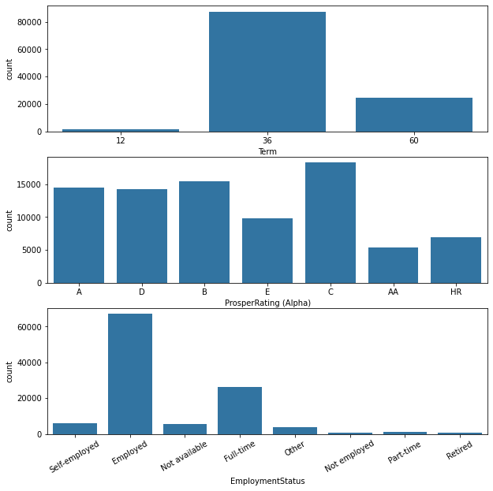

```python
fig, axs = plt.subplots(3, figsize=(10,10))
sb.countplot(data = sub_loan, x = 'Term',color=  sb.color_palette()[0], ax=axs[0]);
sb.countplot(data = sub_loan, x = 'ProsperRating (Alpha)',color=  sb.color_palette()[0],ax=axs[1]);
sb.countplot(data = sub_loan, x = 'EmploymentStatus',color=  sb.color_palette()[0], ax=axs[2]);
plt.xticks(rotation=30)
```

> Most of the loans are for period of 36 months followed by 60

> Most of the loan borrowers rating is between A and D

> Most of the borrowers are employed and full time

```python
print(sub_loan.Occupation.value_counts())
df_occ_type=  pd.DataFrame(sub_loan.groupby(['Occupation'],as_index=False).Term.count())
df_occ_type = df_occ_type.nlargest(10, 'Term',keep='first')
df_occ_type.head()
```

```
Other                          28569
Professional                   13582
Computer Programmer             4476
Executive                       4231
Teacher                         3759
                               ...
Dentist                           66
Student - College Freshman        41
Student - Community College       28
Judge                             22
Student - Technical School        16
Name: Occupation, Length: 67, dtype: int64
```

|  | Occupation | Term |
| --- | --- | --- |
| 35 | Other | 28569 |
| 41 | Professional | 13582 |
| 12 | Computer Programmer | 4476 |
| 19 | Executive | 4231 |
| 59 | Teacher | 3759 |

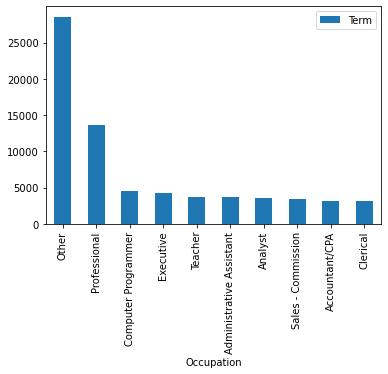

```python
df_occ_type.plot(x= 'Occupation', y='Term', kind='bar');
```

> Major occupation of borrowers is professional followed by Computer programmer, executive and teacher

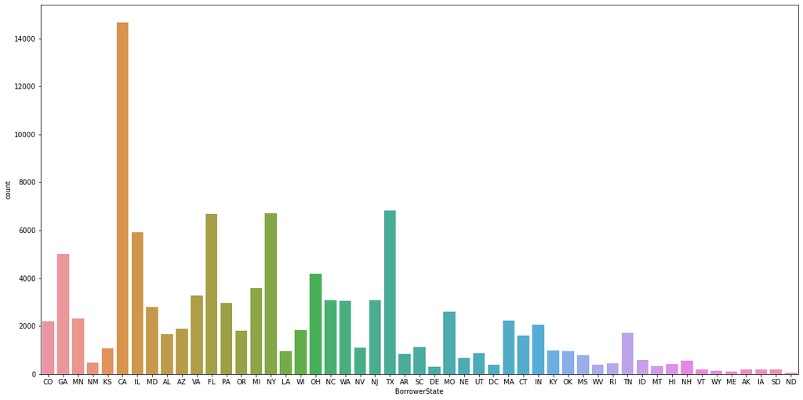

```python
fig,ax=plt.subplots(figsize=(20,10))
sb.countplot(data= sub_loan, x= 'BorrowerState', ax=ax)
```

> Most of the borrowers are from state CA followed by TX, NY, FL

```python
sub_loan.ProsperScore.value_counts()
```

```
4.0     12558
6.0     12264
8.0     12008
7.0     10569
5.0      9794
3.0      7621
9.0      6879
2.0      5757
10.0     4722
11.0     1443
1.0       989
Name: ProsperScore, dtype: int64
```

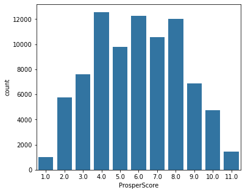

```python
fig,ax=plt.subplots(figsize=(6,5))
sb.countplot(data= sub_loan, x= 'ProsperScore', ax=ax, color=  sb.color_palette()[0]);
```

> Prosper Score is mostly between 4 and 8 with highest score 4 followed by 6 and 8

### Discuss the distribution(s) of your variable(s) of interest. Were there any unusual points? Did you need to perform any transformations?

> The distribution of APR looks multimodal. A small peak centered at 0.1, a large peak centered at 0.2. There is also a small peak centered 0.3. Additionally, there is a very shape peak between 0.35 and 0.36. Only very few loans have APR greater than 0.43.

### Of the features you investigated, were there any unusual distributions? Did you perform any operations on the data to tidy, adjust, or change the form of the data? If so, why did you do this?

> Stated monthly income was skewed with only 0.28% values greater than 30,000. The largest value was quite high ie 17,50,002. We ignored values > 30k as these can be considered as outliers

## Bivariate Exploration

> In this section,I'll investigate relationships between pairs of variables in my data.

First of all lets divide the variables into numerical variables and categorical variables

> Numerical= [LoanOriginalAmount, BorrowerAPR, StatedMonthlyIncome, BorrowerRate,ProsperScore]

> Categorical = [Term,ProsperRating (Alpha), EmploymentStatus, Occupation,BorrowerState]

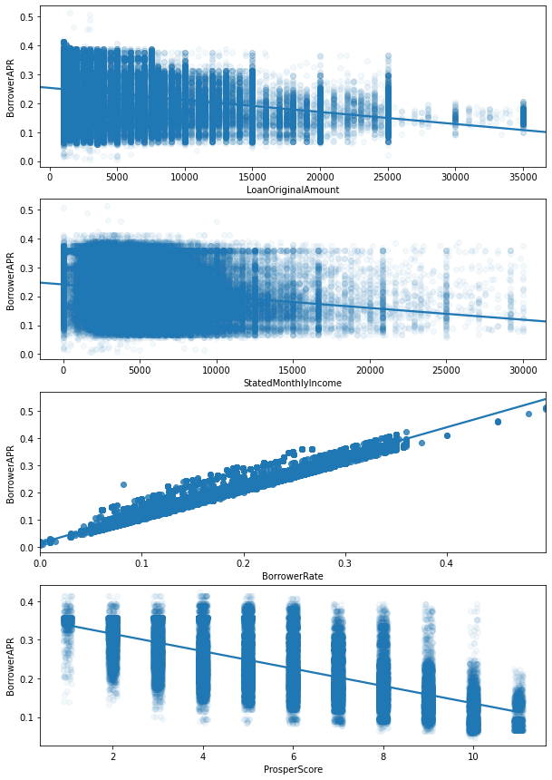

```python
#Finding relation between numerical values
fig, ax= plt.subplots(4, figsize=(10,15))
# subplot 1: BorrowerAPR vs LoanOriginalAmount
sb.regplot(data = sub_loan, x = 'LoanOriginalAmount', y = 'BorrowerAPR', ax=ax[0],x_jitter= 0.1, truncate=False, scatter_kws={'alpha':1/20})

# subplot 2: BorrowerAPR vs StatedMonthlyIncome
sb.regplot(data = sub_loan, x = 'StatedMonthlyIncome', y = 'BorrowerAPR', ax=ax[1], x_jitter=0.1, truncate=False,scatter_kws={'alpha':1/20})

# subplot 3: BorrowerAPR  vs BorrowerRate
sb.regplot(data = sub_loan, x = 'BorrowerRate', y = 'BorrowerAPR', ax=ax[2])

#subplot 4: BorrowerAPR vs ProsperScore
sb.regplot(data = sub_loan, x = 'ProsperScore', y = 'BorrowerAPR', ax=ax[3], x_jitter=0.1,scatter_kws={'alpha':1/20});
```

> A positive correlation seen between APR and borrower rate Borrower APR decreases with increasing Loan amount For low prosper score the Borrower APR is high and for high prosper score the borrower APR is low

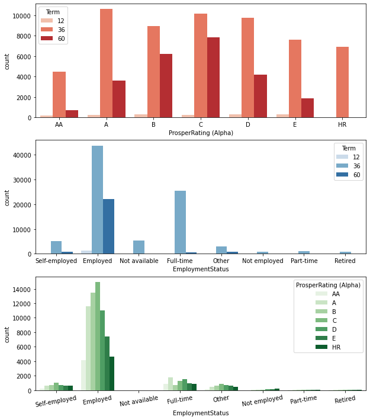

```python
#Finding relations between categorical values
fig, ax= plt.subplots(3, figsize=(10,12))
# subplot 1: Prosper rating vs term
PR_order = ['AA','A', 'B','C','D','E','HR']
# Returns the types for PR_order with the categories and orderedness
vclasses1 = pd.api.types.CategoricalDtype(ordered=True, categories=PR_order)
# Use pandas.astype() to convert the "vordered" column from a plain object type into an ordered categorical type
sub_loan['ProsperRating (Alpha)'] = sub_loan['ProsperRating (Alpha)'].astype(vclasses1)
sb.countplot(data = sub_loan, x = 'ProsperRating (Alpha)', hue = 'Term', palette = 'Reds', ax=ax[0])

# subplot 2: employment status vs term
sb.countplot(data = sub_loan, x = 'EmploymentStatus', hue = 'Term', palette = 'Blues', ax=ax[1])

# subplot 3: Prosper rating vs employment status

sb.countplot(data = sub_loan, x = 'EmploymentStatus', hue = 'ProsperRating (Alpha)', palette = 'Greens', ax=ax[2])
plt.xticks(rotation=10);
#leaving occupation and state because of large number of value counts
```

> Most of the loans are for 36 months term despite the prosper rating. Most of the loans are taken by employed and full time workers with term of 36 months The most common rating for employed and self employed is C. For full time the most common rating is A

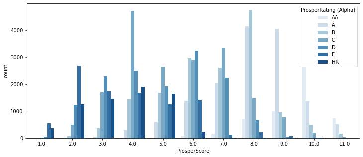

```python
#trying to find a relation between prosper rating and prosper score
fig, ax= plt.subplots(figsize=(12,5))
sb.countplot(data= sub_loan, hue='ProsperRating (Alpha)', x= 'ProsperScore', palette= 'Blues');
```

> We see that as the prosper score increased rating A and AA increased. Prosper score 10 and 11 had largest AA rating and prosper score of 8 and 9 have large number of A ratings. On the other hand prosper score of 1 and 2 have E and HR rating

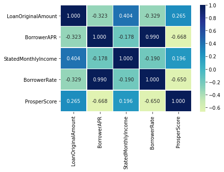

```python
#correlation plot between the numerical variables
v_num = ['LoanOriginalAmount', 'BorrowerAPR', 'StatedMonthlyIncome','BorrowerRate','ProsperScore']
sb.heatmap(sub_loan[v_num].corr(method='pearson'), annot=True, linewidth= 0.5, cmap='YlGnBu', center=0,fmt = '.3f');
```

> We see a strong positive correlation between Borrower APR and borrower rate, which is quite obvious

> A negative correlation of 0.323 is observed between Borrower APR and Loan Original Amount, which shows tha as the loan amount increases the APR decreases

> A negative correlation of 0.178 is observed between Borrower APR and Stated Monthly Income, which shows that as the monthly income increases the APR decreases. We can also see that there is positive correlation between loan original amount and monthly income

> Prosper score is strongly negatively correlated with Borrower APR, ie rating increases with decrease in borrower APR

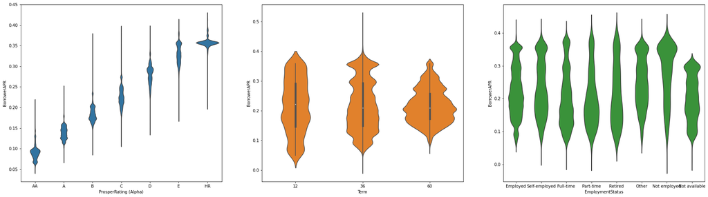

```python
plt.figure(figsize = [30, 8])
PR_order = ['AA','A', 'B','C','D','E','HR']
# Returns the types for PR_order with the categories and orderedness
vclasses1 = pd.api.types.CategoricalDtype(ordered=True, categories=PR_order)
# Use pandas.astype() to convert the "vordered" column from a plain object type into an ordered categorical type
sub_loan['ProsperRating (Alpha)'] = sub_loan['ProsperRating (Alpha)'].astype(vclasses1)
plt.subplot(1, 3, 1)
sb.violinplot(data=sub_loan, x='ProsperRating (Alpha)', y='BorrowerAPR',inner=None, color= sb.color_palette()[0]);
plt.subplot(1, 3, 2)
sb.violinplot(data=sub_loan, x='Term', y='BorrowerAPR', color= sb.color_palette()[1]);
plt.subplot(1, 3, 3)
ES_order = ['Employed','Self-employed','Full-time','Part-time','Retired','Other','Not employed', 'Not available']
# Returns the types for PR_order with the categories and orderedness
vclasses2 = pd.api.types.CategoricalDtype(ordered=True, categories=ES_order)
# Use pandas.astype() to convert the "vordered" column from a plain object type into an ordered categorical type
sub_loan['EmploymentStatus'] = sub_loan['EmploymentStatus'].astype(vclasses2)
sb.violinplot(data=sub_loan, x='EmploymentStatus', y='BorrowerAPR',inner=None, color= sb.color_palette()[2]);
```

##### Borrower APR vs Prosper Rating (Alpha)

> We see borrower APR decreases with the increasing better rating.Borrowers with AA rating have the least APR

##### Borrower APR vs Employment Status

> For not employed there is a bulge at higher APR. We can say they have higher APR. There is a bulge at lowe APr values for others who are employed, self employed, part time or full time and retired. Not much can be observed for others

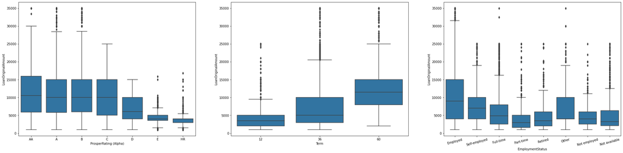

```python
plt.figure(figsize = [35, 8])
plt.subplot(1,3,1)
sb.boxplot(data=sub_loan, x='ProsperRating (Alpha)', y='LoanOriginalAmount', color=sb.color_palette()[0])
plt.subplot(1,3,2)
sb.boxplot(data=sub_loan, x='Term', y='LoanOriginalAmount', color=sb.color_palette()[0])
plt.subplot(1,3,3)
sb.boxplot(data=sub_loan, x='EmploymentStatus', y='LoanOriginalAmount', color=sb.color_palette()[0])
plt.xticks(rotation=15);
```

> Loan amount is reduced with the decreasing rating value

> Loan amount is higher for higher term

> Loan amount is higher for employed, self employed full time and others

### Were there any interesting or surprising interactions between features?

> The loan original amount is positively correlated with the stated monthly income. Positive correlation between prosper score and loan amount as well as prosper score and stated monthly income which can be because of the fact that the person with more income has better prosper score

## Multivariate Exploration

> Here we will explore the relationship between numerical variables and categorical varaiables

> Case : APR , LoanOriginalAmount,StatedMonthlyIncome affected by Term,ProsperRating (Alpha),Employment Status

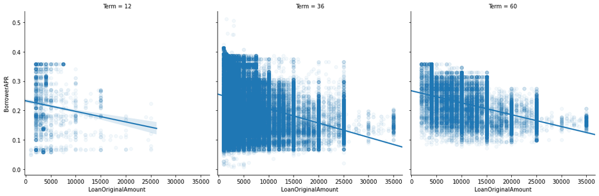

```python
#APR and LoanOriginalAmount affected by Term
plt.figure(figsize = [8, 8])
g = sb.FacetGrid(data = sub_loan, col = 'Term', height = 5,
                margin_titles = True)
g.map(sb.regplot, 'LoanOriginalAmount', 'BorrowerAPR',x_jitter= 0.1, truncate=False, scatter_kws={'alpha':1/20});
```

> Loan amount vs Borrower APR seems unphased by the term. We just observe more loans for 36 months term

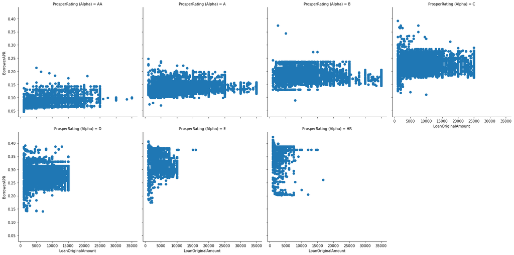

```python
#APR and LoanOriginalAmount affected by ProsperRating
plt.figure(figsize = [10, 10])
g = sb.FacetGrid(data = sub_loan, col = 'ProsperRating (Alpha)', height = 5,
                margin_titles = True, col_wrap=4, )
g.map(plt.scatter, 'LoanOriginalAmount', 'BorrowerAPR');
```

> Loan original amount increases with increasingly better rating. Also the borrower APR decreases with better rating. For bad ratings APR vary a lot for the same loan amount whereas for good ratig there is less variation in APR.

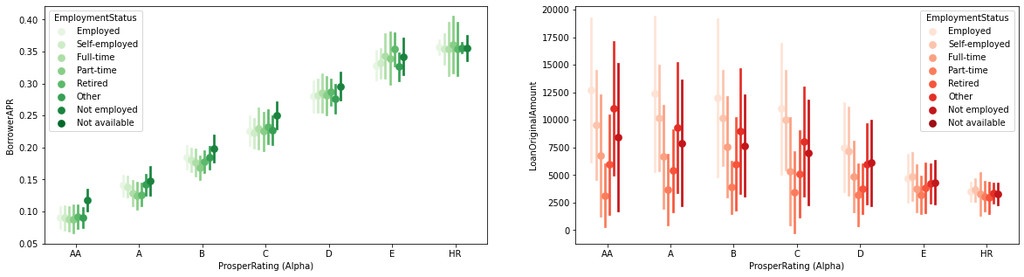

```python
#APR and LoanOriginalAmount affected by EmploymentStatus
plt.figure(figsize = [20, 5])
plt.subplot(1,2,1)
ax= sb.pointplot(data = sub_loan, x = 'ProsperRating (Alpha)', y = 'BorrowerAPR', hue = 'EmploymentStatus',
                  dodge = 0.5, linestyles = "", ci='sd', palette= 'Greens');
#ProsperRating and LoanOriginalAmount affected by EmploymentStatus
plt.subplot(1,2,2)
ax2= sb.pointplot(data = sub_loan, x = 'ProsperRating (Alpha)', y = 'LoanOriginalAmount', hue = 'EmploymentStatus',
                  dodge = 0.5, linestyles = "", ci='sd', palette= 'Reds');
```

> The borrower APR increase for not employed from AA to B ratings. But for C to HR ratings, the APR decrease for not employed

> For higher prosper rating employed people get larger amount as loan. That difference minimises as we move to low ratings

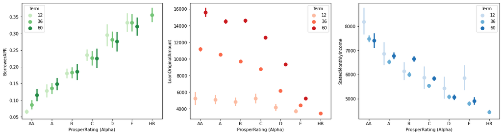

```python
#ProsperRating and BorrowerAPR affected by term
plt.figure(figsize = [20, 5])
plt.subplot(1,3,1)
ax= sb.pointplot(data = sub_loan, x = 'ProsperRating (Alpha)', y = 'BorrowerAPR', hue = 'Term',
                  dodge = 0.5, linestyles = "", ci='sd', palette= 'Greens');
#ProsperRating and LoanOriginalAmount affected by Term
plt.subplot(1,3,2)
ax2= sb.pointplot(data = sub_loan, x = 'ProsperRating (Alpha)', y = 'LoanOriginalAmount', hue = 'Term',
                  dodge = 0.5, linestyles = "",  palette= 'Reds');
#ProsperRating and StatedMonthlyIncome affected by Term
plt.subplot(1,3,3)
ax2= sb.pointplot(data = sub_loan, x = 'ProsperRating (Alpha)', y = 'StatedMonthlyIncome', hue = 'Term',
                  dodge = 0.5, linestyles = "", palette= 'Blues');
```

> The borrower APR decrease with the increase in term from C to HR ratings. But for B to AA ratings, the APR increase with the increase of term

> For loan original amount we can see that with better Prosper rating, the loan amount of all three terms increases. The loan amount for all the three terms also increase with increasing rating

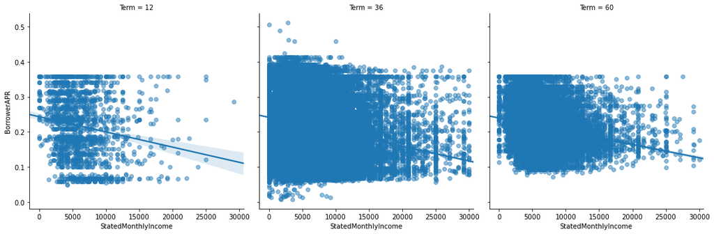

```python
#APR and StatedMonthlyIncome affected by Term
plt.figure(figsize = [8, 8])
g = sb.FacetGrid(data = sub_loan, col = 'Term', height = 5,
                margin_titles = True)
g.map(sb.regplot, 'StatedMonthlyIncome', 'BorrowerAPR',x_jitter= 0.1, truncate=False, scatter_kws={'alpha':0.5});
```

> Borrower APR vs Stated monthly income seems not much affected by the term of loan. It can be observed that most of the loans are of 36 months term followed by 60 months

### Were there any interesting or surprising interactions between features?

> The borrower APR decrease with the increase in term from C to HR ratings. But for B to AA ratings, the APR increase with the increase of term